# A Brief R Markdown Tutorial

Zheng Tian

# 1 R Markdown

R Markdown provides an authoring framework for data science. You can use a single R Markdown file to both

- save and execute code
- generate high quality reports that can be shared with an audience

This document gives you a very brief tutorial for R Markdown. You can also read tutorial documents in the this link, http://rmarkdown.rstudio.com/lesson-1.html.

## 1.1 Create a R Markdown file

An R Markdown file is a plain text file that has the extension `.Rmd`. In RStudio, you can easily create a new R Markdown file through the following steps:

1. Click `File -> New File -> R Markdown`.
2. At the left panel in the window jumping up, choose `Document`, and at the right panel, enter the title and author name of the document. Then, choose `HTML` as the default output format and click `OK`.

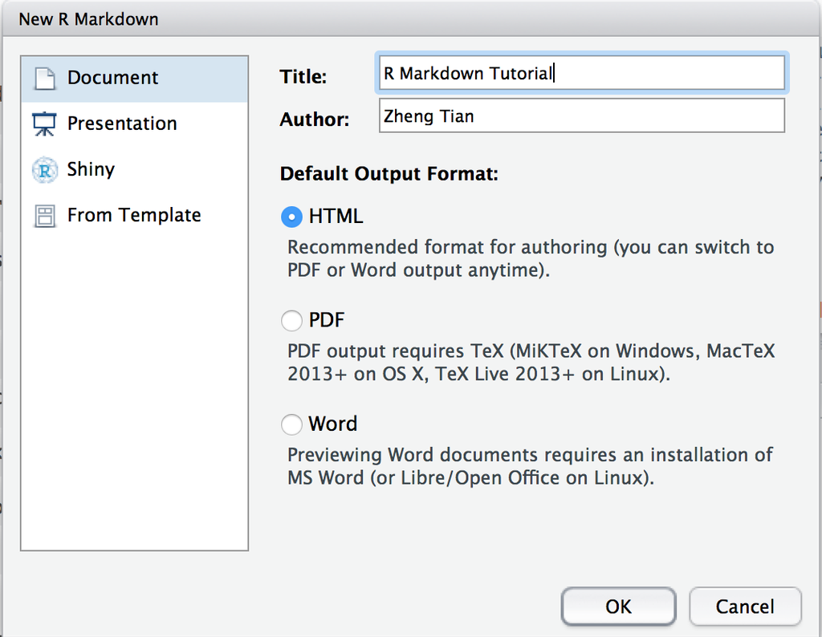

3. A short R Markdown document is generated with some elements in it as a template.

## 1.2 How R Markdown works

The underlying mechanism of R Markdown is shown as follows

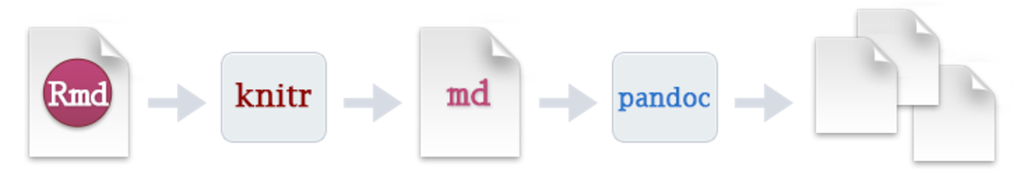

R Markdown Workflow

- To generate an `HTML` document from a R Markdown file, click `Knit` button in RStudio.
- A built-in HTML browser will be invoked to have a preview of the document.
- You can also create a PDF file by click the little arrow beside `Knit` button, and choose `Knit to PDF`.

# 2 The Elements in a R Markdown File

## 2.1 The Paragraph

A new paragraph is created by following one or more blank lines.

## 2.2 Headers and sections

The `#` sign defines a top-level header and a section, `##` defines a level-two header and a subsection.

```
# Section
## A subsection
### A subsubsection
```

## 2.3 Emphasis

Markdown uses `**bold**` to use the **bold** font and `*italic*` to use the *italic* font.

## 2.4 List

We can create a list as follows,

```
* Item 1
* Item 2
    + Item 2a
    + Item 2bn
```

- Item 1
- Item 2
  - Item 2a
  - Item 2b

The list can also be numbered as follows,

```
1. Item 1
2. Item 2
3. Item 3
    + Item 3a
    + Item 3b
```

## 2.5 Equations

R Markdown uses the LaTeX command to create mathematical expressions.

For example, the linear regression equation in display mode is

```
  \[Y_i = \beta_0 + \beta_1 X_i + u_i, \text{ for } i = 1, \ldots, n\]
```

which generates
$$Y_i = \beta_0 + \beta_1 X_i + u_i, \text{ for } i = 1, \ldots, n$$

And the in-line mathematical expression is `$\beta_1 = \frac{\Delta Y}{\Delta X}$`, generating $\beta_1 = \frac{\Delta Y}{\Delta X}$.

# 3 R Code Chunk

Most importantly, we can include R code along with the output in a R Markdown file. You can quickly insert chunks like these into your file with

- the keyboard shortcut `Ctrl + Alt + I` (OS X: `Cmd + Option + I`)
- the `Insert` button in the editor toolbar
- or by typing the chunk delimiters ```{r} and ```.

The behaviors of the R code chunk can be controlled by adding options.

```r
summary(mtcars[, 1:3])
```

```
##       mpg             cyl             disp
##  Min.   :10.40   Min.   :4.000   Min.   : 71.1
##  1st Qu.:15.43   1st Qu.:4.000   1st Qu.:120.8
##  Median :19.20   Median :6.000   Median :196.3
##  Mean   :20.09   Mean   :6.188   Mean   :230.7
##  3rd Qu.:22.80   3rd Qu.:8.000   3rd Qu.:326.0
##  Max.   :33.90   Max.   :8.000   Max.   :472.0
```

The options that are often used include `echo`, `results`, `include`, and `eval`, etc.

```r
library(knitr)
kable(mtcars[1:5, 1:3])
```

|  | mpg | cyl | disp |
| --- | --- | --- | --- |
| Mazda RX4 | 21.0 | 6 | 160 |
| Mazda RX4 Wag | 21.0 | 6 | 160 |
| Datsun 710 | 22.8 | 4 | 108 |
| Hornet 4 Drive | 21.4 | 6 | 258 |
| Hornet Sportabout | 18.7 | 8 | 360 |

We can also embed plots, for example:

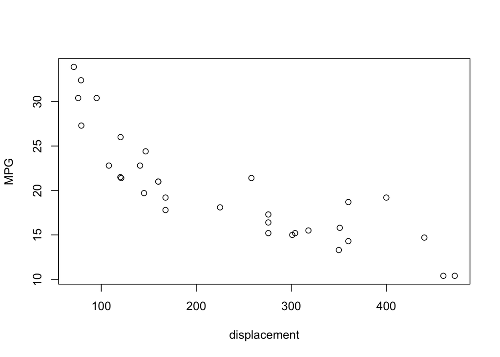

A Scatterplot

```r
  plot(mtcars$disp, mtcars$mpg,
       xlab = "displacement", ylab = "MPG")
```

Finally, we use the following reference card to quickly find the relevant command in R Markdown, rmarkdown_cheatsheet.pdf.